# Ligand Activity Regressions: AMP 2023 (rheumatoid arthritis)

EYW

2026-08-17

```r
knitr::opts_chunk$set(echo = TRUE)
source("regression_helpers.R")
```

# Goal

Test which SIG13 ligand activities differ in RA synovial CD4 T cells (AMP Phase 2), using the activity scores from `02_score_disease_datasets.py`.

Two questions, each asked across all CD4 T cells and per celltype:

1. **Disease** – RA vs osteoarthritis control
2. **CTAP** – do the AMP cell-type-abundance phenotypes (the synovial tissue “neighbourhoods”) differ in the combinatorial signals CD4 T cells experience?

**Covariates:** sex, scaled age, and joint in every model. Age is complete for all 77 biopsies, so unlike the atlas there is no missingness argument for binning it. Joint matters most: the osteoarthritis controls are drawn from different joints than the RA biopsies (RA is mostly knee and wrist), so it is adjusted for throughout. The earlier analysis omitted age from the celltype models but not the whole-biopsy ones.

# Import

```r
AMP_KEYS <- c("subject_id", "biopsy_id", "joint", "sex", "treatment", "CTAP",
              "das28_crp3_binary")

# `Repeat` biopsies are repeat sampling of the same joint, excluded here; they are
# also exactly the samples with no CTAP assignment.
prepare_amp <- function(df) {
  df %>%
    filter(treatment != "Repeat") %>%
    mutate(disease_binary = factor(ifelse(treatment == "osteoarthritis control",
                                          "control", "RA"), c("RA", "control")),
           das28_crp3_binary = factor(das28_crp3_binary, c("high", "low", "control")),
           across(c(sex, joint, CTAP), factor),
           age = as.vector(scale(age)))
}

amp <- load_activity_scores("amp_2023", AMP_KEYS) %>% prepare_amp()
amp_celltype <- load_activity_scores("amp_2023_celltype", c(AMP_KEYS, "cluster_name")) %>%
  rename(celltype = cluster_name) %>%
  prepare_amp() %>%
  mutate(celltype = fct_relevel(factor(celltype), "T-4: CD4+ naive"))

activities <- activity_names()
cat(nrow(amp), "biopsies,", length(activities), "ligand activities\n")
```

```
## 77 biopsies, 38 ligand activities
```

```r
count(amp, disease_binary, CTAP)
```

```
## # A tibble: 7 × 3
##   disease_binary CTAP          n
##   <fct>          <fct>     <int>
## 1 RA             E + F + M     7
## 2 RA             F            11
## 3 RA             M            18
## 4 RA             T + B        14
## 5 RA             T + F         8
## 6 RA             T + M        12
## 7 control        control       7
```

# Covariate QC

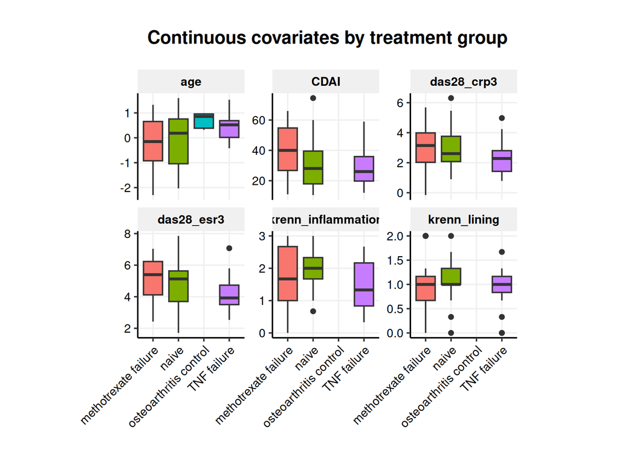

```r
amp %>%
  pivot_longer(c(age, CDAI, das28_crp3, das28_esr3, krenn_inflammation, krenn_lining),
               names_to = "variable", values_to = "value") %>%
  ggplot(aes(x = treatment, y = value, fill = treatment)) +
  geom_boxplot(show.legend = FALSE, na.rm = TRUE) +
  facet_wrap(~variable, scales = "free_y") +
  theme(axis.text.x = element_text(angle = 45, hjust = 1),
        aspect.ratio = 1) +
  labs(title = "Continuous covariates by treatment group", x = "", y = "")
```

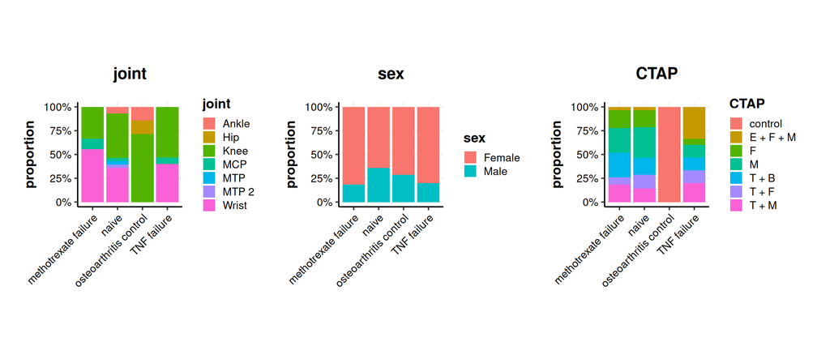

```r
map(c("joint", "sex", "CTAP"), function(variable) {
  ggplot(amp, aes(x = treatment, fill = !!sym(variable))) +
    geom_bar(position = "fill") +
    scale_y_continuous(labels = scales::percent) +
    theme(axis.text.x = element_text(angle = 45, hjust = 1),
          aspect.ratio = 1) +
    labs(title = variable, x = "", y = "proportion")
}) %>% wrap_plots(nrow = 1)
```

Joint is the one notable imbalance – the osteoarthritis controls are dominated by one joint – so it is adjusted for in every model below.

# Disease associations

```r
res_disease <- fit_and_save(
  amp,
  rhs = "disease_binary + sex + age + joint",
  emm = ~ disease_binary,
  contrast_args = list(method = "pairwise"),
  name = "amp_2023_disease_binary"
)
```

```
## amp_2023_disease_binary: 38 contrast x activity rows, 0 with padj < 0.1
```

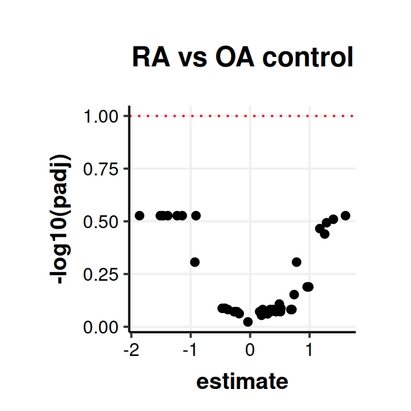

```r
res_disease %>%
  ggplot(aes(x = estimate, y = -log10(padj))) +
  geom_point() +
  geom_hline(yintercept = 1, linetype = "dotted", color = "red") +
  theme(aspect.ratio = 1) +
  labs(title = "RA vs OA control")
```

# CTAP associations

Each CTAP against the osteoarthritis controls. Disease severity is not adjusted for here because it is undefined for the controls.

```r
res_ctap <- fit_and_save(
  amp,
  rhs = "CTAP + sex + age + joint",
  emm = ~ CTAP,
  contrast_args = list(method = "trt.vs.ctrl", ref = "control"),
  name = "amp_2023_ctap_control_ref"
)
```

```
## amp_2023_ctap_control_ref: 228 contrast x activity rows, 24 with padj < 0.1
```

# Celltype associations

Which activities distinguish CD4 subsets from each other, irrespective of disease. `del.eff` contrasts each celltype against the mean of the others; HC3 robust covariance is used because the per-celltype sample sizes are uneven.

```r
res_celltype <- fit_and_save(
  amp_celltype,
  rhs = "celltype + sex + age + joint",
  emm = ~ celltype,
  contrast_args = list(method = "del.eff"),
  robust = TRUE,
  name = "amp_2023_celltype"
)
```

```
## amp_2023_celltype: 494 contrast x activity rows, 264 with padj < 0.1
```

## Disease x celltype

```r
res_disease_celltype <- fit_and_save(
  amp_celltype,
  rhs = "disease_binary * celltype + sex + age + joint",
  emm = ~ disease_binary | celltype,
  contrast_args = list(method = "pairwise"),
  padj_by = c("contrast", "celltype"),
  name = "amp_2023_disease_celltype"
)
```

```
## amp_2023_disease_celltype: 494 contrast x activity rows, 58 with padj < 0.1
```

## CTAP x celltype

HC3 is unstable for this model (many CTAP x celltype cells are small), so model-based standard errors are used.

```r
res_ctap_celltype <- fit_and_save(
  amp_celltype,
  rhs = "CTAP * celltype + sex + age + joint",
  emm = ~ CTAP | celltype,
  contrast_args = list(method = "trt.vs.ctrl", ref = "control"),
  padj_by = c("contrast", "celltype"),
  name = "amp_2023_ctap_celltype_control_ref"
)
```

```
## amp_2023_ctap_celltype_control_ref: 2964 contrast x activity rows, 317 with padj < 0.1
```

```r
res_ctap_celltype %>%
  filter(padj < 0.1) %>%
  count(celltype, name = "significant_activity_contrasts") %>%
  arrange(desc(significant_activity_contrasts))
```

```
## # A tibble: 13 × 2
##    celltype                    significant_activity_contrasts
##    <chr>                                                <int>
##  1 T-8: CD4+ CD25-high Treg                                88
##  2 T-7: CD4+ IFNG+ Tph/Tfh                                 47
##  3 T-10: CD4+ OX40+NR3C1+                                  40
##  4 T-2: CD4+ IL7R+CCR5+ memory                             23
##  5 T-6: CD4+ memory                                        23
##  6 T-0: CD4+ IL7R+ memory                                  21
##  7 T-11: CD4+ CD146+ memory                                18
##  8 T-9: CD4+ CD25-low Treg                                 15
##  9 T-1: CD4+ CD161+ memory                                 13
## 10 T-4: CD4+ naive                                         13
## 11 T-12: CD4+ GNLY+                                         8
## 12 T-3: CD4+ IFNG- Tph/Tfh                                  7
## 13 T-5: CD4+ GZMK+ memory                                   1
```

Results are written to `analysis_outs/inference_model_disease_bulk/regressions/` and visualized in `09_viz_amp_2023.Rmd`.